# Clase 3: Modelos de Regresión

### Selección de grado con validación

Para esta y la siguiente sección estudiaremos el **Conjunto de datos de vivienda de Boston** que consiste en el precio de las casas en varios lugares de Boston. Junto con el precio, el conjunto de datos también proporciona información como la tasa de criminalidad (CRIM), áreas de negocios no minoristas en la ciudad (INDUS), la edad de las personas que poseen la casa (EDAD) y hay muchos otros atributos

```python
#5.2.1. Boston house prices dataset

# display an Inline Frame
from IPython.display import IFrame
IFrame('https://scikit-learn.org/stable/datasets/index.html#boston-dataset',
       width=750, height=500)
```

[interactive chart not shown]

```python
#load the Boston data set in it's original format (dictionary)
from sklearn.datasets import load_boston
raw_data = load_boston()

# Create a Pandas Data Frame with the Boston data
boston = pd.DataFrame(raw_data.data)
boston.columns = raw_data.feature_names
boston['PRICE'] = raw_data.target
display(boston.head(10))
```

|  | CRIM | ZN | INDUS | CHAS | NOX | RM | AGE | DIS | RAD | TAX | PTRATIO | B | LSTAT | PRICE |
| --- | --- | --- | --- | --- | --- | --- | --- | --- | --- | --- | --- | --- | --- | --- |
| 0 | 0.00632 | 18.0 | 2.31 | 0.0 | 0.538 | 6.575 | 65.2 | 4.0900 | 1.0 | 296.0 | 15.3 | 396.90 | 4.98 | 24.0 |
| 1 | 0.02731 | 0.0 | 7.07 | 0.0 | 0.469 | 6.421 | 78.9 | 4.9671 | 2.0 | 242.0 | 17.8 | 396.90 | 9.14 | 21.6 |
| 2 | 0.02729 | 0.0 | 7.07 | 0.0 | 0.469 | 7.185 | 61.1 | 4.9671 | 2.0 | 242.0 | 17.8 | 392.83 | 4.03 | 34.7 |
| 3 | 0.03237 | 0.0 | 2.18 | 0.0 | 0.458 | 6.998 | 45.8 | 6.0622 | 3.0 | 222.0 | 18.7 | 394.63 | 2.94 | 33.4 |
| 4 | 0.06905 | 0.0 | 2.18 | 0.0 | 0.458 | 7.147 | 54.2 | 6.0622 | 3.0 | 222.0 | 18.7 | 396.90 | 5.33 | 36.2 |
| 5 | 0.02985 | 0.0 | 2.18 | 0.0 | 0.458 | 6.430 | 58.7 | 6.0622 | 3.0 | 222.0 | 18.7 | 394.12 | 5.21 | 28.7 |
| 6 | 0.08829 | 12.5 | 7.87 | 0.0 | 0.524 | 6.012 | 66.6 | 5.5605 | 5.0 | 311.0 | 15.2 | 395.60 | 12.43 | 22.9 |
| 7 | 0.14455 | 12.5 | 7.87 | 0.0 | 0.524 | 6.172 | 96.1 | 5.9505 | 5.0 | 311.0 | 15.2 | 396.90 | 19.15 | 27.1 |
| 8 | 0.21124 | 12.5 | 7.87 | 0.0 | 0.524 | 5.631 | 100.0 | 6.0821 | 5.0 | 311.0 | 15.2 | 386.63 | 29.93 | 16.5 |
| 9 | 0.17004 | 12.5 | 7.87 | 0.0 | 0.524 | 6.004 | 85.9 | 6.5921 | 5.0 | 311.0 | 15.2 | 386.71 | 17.10 | 18.9 |

```python
# definimos una función para el pipeline de la regresion polinomial
def PolynomialRegression(degree=2, **kwargs):
    return make_pipeline(PolynomialFeatures(degree),
                         LinearRegression(**kwargs))
```

```python
# obtenemos datos univariados del dataset de boston
X = boston.LSTAT.values.reshape(-1, 1)
y = boston.PRICE.values.reshape(-1, 1)
```

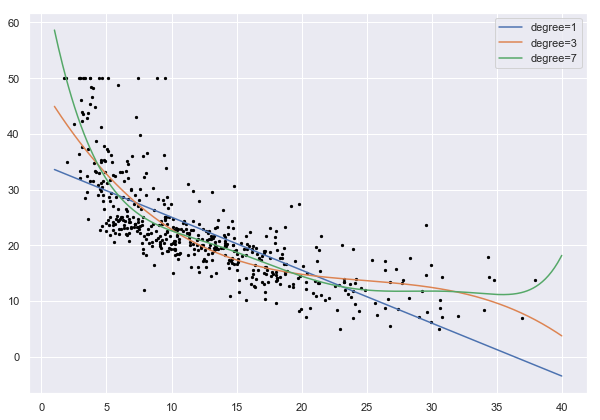

```python
%matplotlib inline
import seaborn; seaborn.set()  # plot formatting

X_test = np.linspace(1, 40, 500)[:, None]

fig = plt.figure(figsize=(10,7))
plt.scatter(X.ravel(), y, color='black',s=5)
axis = plt.axis()
for degree in [1, 3, 7]:
    y_test = PolynomialRegression(degree).fit(X, y).predict(X_test)
    plt.plot(X_test.ravel(), y_test, label='degree={0}'.format(degree))
#plt.xlim(-0.1, 1.0)
#plt.ylim(-2, 12)
plt.legend(loc='best');
```

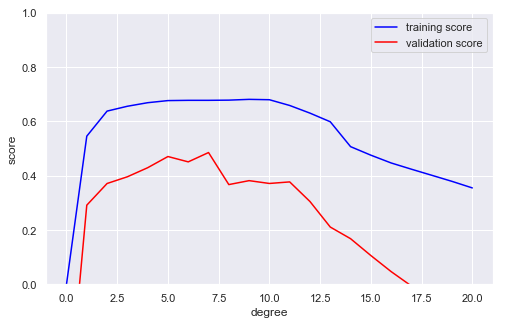

```python
from sklearn.model_selection import validation_curve
degree = np.arange(0, 21)
train_score, val_score = validation_curve(PolynomialRegression(), X, y,
                                          'polynomialfeatures__degree', degree, cv=7)

fig = plt.figure(figsize=(8,5))
plt.plot(degree, np.median(train_score, 1), color='blue', label='training score')
plt.plot(degree, np.median(val_score, 1), color='red', label='validation score')
plt.legend(loc='best')
plt.ylim(0, 1)
plt.xlabel('degree')
plt.ylabel('score');
```

#### Validación con GridSearchCV

[figure not shown]

```python
from sklearn.model_selection import GridSearchCV

param_grid = {'polynomialfeatures__degree': np.arange(21),
              'linearregression__fit_intercept': [True, False],
              'linearregression__normalize': [True, False]}

grid = GridSearchCV(PolynomialRegression(), param_grid, cv=5)
```

```python
# ajustamos el GridSearchCV a los datos
grid.fit(X, y);
```

```python
grid.best_params_
```

```
{'linearregression__fit_intercept': False,
 'linearregression__normalize': True,
 'polynomialfeatures__degree': 5}
```

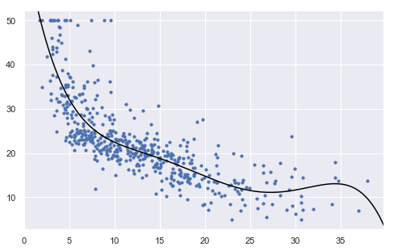

```python
model = grid.best_estimator_

fig = plt.figure(figsize=(8,5))
plt.scatter(X.ravel(), y, s=10)
lim = plt.axis()
y_test = model.fit(X, y).predict(X_test)
plt.plot(X_test.ravel(), y_test, color='black');
plt.axis(lim);
```

## 3. Regularización Ridge y Lasso

La regresión de Ridge y Lasso son técnicas generalmente utilizadas para crear modelos que generealicen bien al tener una gran cantidad de variables. Aquí "grande" puede significar cualquiera de dos cosas:

- Lo suficientemente grande como para mejorar la tendencia de un modelo a sobreajustar
- Lo suficientemente grande como para causar desafíos computacionales

Modelos de Regularización:

1. **Ridge:** Realiza la regularización L2, es decir, agrega una penalización equivalente al cuadrado de la magnitud de los coeficientes
2. **Lasso:** Realiza la regularización L1, es decir, agrega una penalización equivalente al valor absoluto de la magnitud de los coeficientes

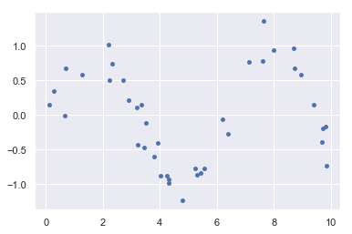

```python
rng = np.random.RandomState(8)
x = 10 * rng.rand(40)
y = np.sin(x) + 0.2 * rng.randn(40)

plt.scatter(x, y, s=15)
plt.show()
```

```python
X_train, X_test, Y_train, Y_test = train_test_split(
    x, y, test_size = 0.3, random_state = 8)
```

```python
from sklearn.base import BaseEstimator, TransformerMixin
class GaussianFeatures(BaseEstimator, TransformerMixin):
    """Uniformly spaced Gaussian features for one-dimensional input"""

    def __init__(self, N, width_factor=2.0):
        self.N = N
        self.width_factor = width_factor

    @staticmethod
    def _gauss_basis(x, y, width, axis=None):
        arg = (x - y) / width
        return np.exp(-0.5 * np.sum(arg ** 2, axis))

    def fit(self, X, y=None):
        # create N centers spread along the data range
        self.centers_ = np.linspace(X.min(), X.max(), self.N)
        self.width_ = self.width_factor * (self.centers_[1] - self.centers_[0])
        return self

    def transform(self, X):
        return self._gauss_basis(X[:, :, np.newaxis], self.centers_,
                                 self.width_, axis=1)
```

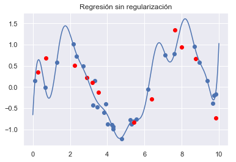

```python
model = make_pipeline(GaussianFeatures(18),
                      LinearRegression())
model.fit(X_train[:, np.newaxis], Y_train)

plt.scatter(X_train, Y_train)
plt.scatter(X_test, Y_test, color='red')
plt.plot(np.linspace(0, 10, 1000), model.predict(xfit[:, np.newaxis]))
plt.title("Regresión sin regularización")
plt.show()
```

```python
mse_train = mean_squared_error(Y_train,model.predict(X_train[:, np.newaxis]))
mse_test = mean_squared_error(Y_test,model.predict(X_test[:, np.newaxis]))
print("El MSE en entrenamiento del modelo Rodge es: {0:.3f}".format(mse_train))
print("El MSE en prueba del modelo Rodge es: {0:.3f}".format(mse_test))
```

```
El MSE en entrenamiento del modelo Rodge es: 0.014
El MSE en prueba del modelo Rodge es: 0.214
```

### Rregresión Ridge

```python
from sklearn.linear_model import Ridge
ridge = make_pipeline(GaussianFeatures(18), Ridge(alpha=0.01))
ridge.fit(X_train[:, np.newaxis],Y_train)
```

```
Pipeline(memory=None,
         steps=[('gaussianfeatures', GaussianFeatures(N=18, width_factor=2.0)),
                ('ridge',
                 Ridge(alpha=0.01, copy_X=True, fit_intercept=True,
                       max_iter=None, normalize=False, random_state=None,
                       solver='auto', tol=0.001))],
         verbose=False)
```

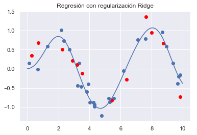

```python
plt.scatter(X_train, Y_train)
plt.scatter(X_test, Y_test, color='red')
plt.plot(np.linspace(0, 10, 1000), ridge.predict(xfit[:, np.newaxis]))
plt.title("Regresión con regularización Ridge")
plt.show()
```

```python
mse_train = mean_squared_error(Y_train,ridge.predict(X_train[:, np.newaxis]))
mse_test = mean_squared_error(Y_test,ridge.predict(X_test[:, np.newaxis]))
print("El MSE en entrenamiento del modelo Ridge es: {0:.3f}".format(mse_train))
print("El MSE en prueba del modelo Ridge es: {0:.3f}".format(mse_test))
```

```
El MSE en entrenamiento del modelo Ridge es: 0.025
El MSE en prueba del modelo Ridge es: 0.079
```

### Regresión Lasso

```python
from sklearn.linear_model import Lasso
lasso = make_pipeline(GaussianFeatures(18), Lasso(alpha=0.01))
lasso.fit(X_train[:, np.newaxis],Y_train)
```

```
Pipeline(memory=None,
         steps=[('gaussianfeatures', GaussianFeatures(N=18, width_factor=2.0)),
                ('lasso',
                 Lasso(alpha=0.01, copy_X=True, fit_intercept=True,
                       max_iter=1000, normalize=False, positive=False,
                       precompute=False, random_state=None, selection='cyclic',
                       tol=0.0001, warm_start=False))],
         verbose=False)
```

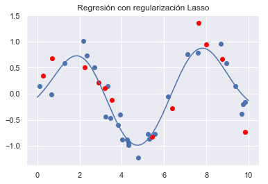

```python
plt.scatter(X_train, Y_train)
plt.scatter(X_test, Y_test, color='red')
plt.plot(np.linspace(0, 10, 1000), lasso.predict(xfit[:, np.newaxis]))
plt.title("Regresión con regularización Lasso")
plt.show()
```

```python
mse_train = mean_squared_error(Y_train,lasso.predict(X_train[:, np.newaxis]))
mse_test = mean_squared_error(Y_test,lasso.predict(X_test[:, np.newaxis]))
print("El MSE en entrenamiento del modelo Lasso es: {0:.3f}".format(mse_train))
print("El MSE en prueba del modelo Lasso es: {0:.3f}".format(mse_test))
```

```
El MSE en entrenamiento del modelo Lasso es: 0.039
El MSE en prueba del modelo Lasso es: 0.094
```

## 4. Linear Discriminant Analysis

El *Linear Discriminant Analysis (LDA)* es una técnica supervisada de reducción de dimensionalidad. El objetivo es proyectar un conjunto de datos en un espacio de dimensiones inferiores con buena capacidad de separación de clases para evitar el sobreajuste y también reducir los costos computacionales.

[figure not shown]

```python
from sklearn.datasets import load_wine #importo datos
from sklearn.discriminant_analysis import LinearDiscriminantAnalysis #importar LDA de scikit learn
```

```python
wine = load_wine()
X = pd.DataFrame(wine.data, columns=wine.feature_names)
y = pd.Categorical.from_codes(wine.target, wine.target_names)
```

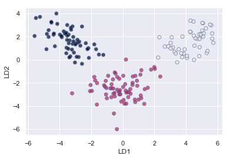

```python
X_lda = LinearDiscriminantAnalysis().fit_transform(X, y)
plt.xlabel('LD1')
plt.ylabel('LD2')
plt.scatter(
    X_lda[:,0],
    X_lda[:,1],
    c=pd.factorize(y)[0] + 1,
    alpha=0.7,
    edgecolors='b'
)
plt.show()
```

## 5. Árboles de regresión

Cubriremos los siguientes temas:

- Selección de hiper-parámetros.
- Interpretación de los árboles.
- Importancia de variables.
- Tipos de ensambles: simulatáneos y secuenciales.
- Regularización de árboles.
- Evaluación de los modelos.

Estudiaremos los siguientes tres modelos:

- Árboles de regresión
- Random Forest (Bosques aleatorios)
- Gradient Boosting Machine

### Árboles de regresión

Los árboles de decisión son formas extremadamente intuitivas para clasificar o etiquetar objetos: simplemente hace una serie de preguntas diseñadas para concentrarse en la regresión o clasificación. Por ejemplo, si desea construir un árbol de decisión para clasificar una casa, puede construir el que se muestra aquí:

[figure not shown]

```python
# import tree from Scikit-Learn
from sklearn import tree
from sklearn.tree import DecisionTreeRegressor
from sklearn.tree import export_graphviz
```

```python
# Separamos las variables independientes y dependiente
X = boston.drop('PRICE', axis = 1)
Y = boston['PRICE']

# importar función para separar dataset en entrenamiento y prueba
from sklearn.model_selection import train_test_split

# Separamos dataset con test del 30% de las observaciones
X_train, X_test, Y_train, Y_test = train_test_split(
    X, Y, test_size = 0.3, random_state = 5)
```

```python
# definimos el arbol de decisión
tree_model = DecisionTreeRegressor(random_state=5)

# ajustar el modelo a los datos
tree_model.fit(X_train, Y_train)
```

```
DecisionTreeRegressor(criterion='mse', max_depth=None, max_features=None,
                      max_leaf_nodes=None, min_impurity_decrease=0.0,
                      min_impurity_split=None, min_samples_leaf=1,
                      min_samples_split=2, min_weight_fraction_leaf=0.0,
                      presort=False, random_state=5, splitter='best')
```

#### Visualización del árbol

```python
# importar los paquetes para visualizar arboles de decision
from graphviz import Source
from IPython.display import Image

# crear la visualizacion como png
graph = Source(tree.export_graphviz(tree_model, out_file=None,
                                     feature_names=X.columns))
png_bytes = graph.pipe(format='png')
with open('dtree_pipe.png','wb') as f:
    f.write(png_bytes)

# mostrar la imagen creada
from IPython.display import Image
print('Double click to zoom')
Image(png_bytes)
```

```
Double click to zoom
```

[figure not shown]

```python
# error de entranamiento y prueba
pred_train = tree_model.predict(X_train)
pred_test= tree_model.predict(X_test)
mse_train = mean_squared_error(Y_train,pred_train)
mse_test = mean_squared_error(Y_test, pred_test)
print("El mse de entrenamiento es: {0:.3f}".format(mse_train))
print("El mse de prueba es: {0:.3f}".format(mse_test))
```

```
El mse de entrenamiento es: 0.000
El mse de prueba es: 32.835
```

**HAY OVERFITTING!!!**

#### Regularización de árboles (*podar el árbol*)

```python
param_grid = {'max_depth': list(range(2,15)),
              'max_leaf_nodes': [5,10,15,20,None]}

grid = GridSearchCV(DecisionTreeRegressor(random_state=5), param_grid, cv=5)
grid.fit(X_train, Y_train)
grid.best_params_
```

[output not shown]

```python
best_tree = grid.best_estimator_
```

```
Double click to zoom
```

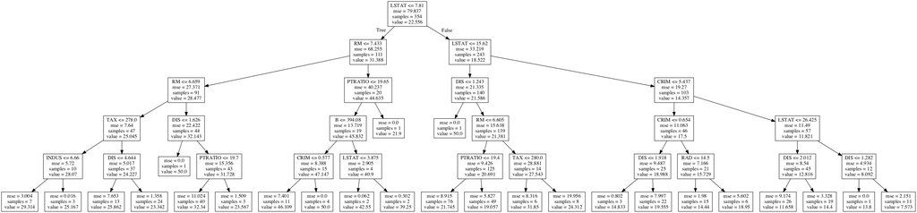

```python
# crear la visualizacion como png
graph = Source(tree.export_graphviz(best_tree, out_file=None,
                                     feature_names=X.columns))
png_bytes = graph.pipe(format='png')
with open('best_tree.png','wb') as f:
    f.write(png_bytes)

# mostrar la imagen creada
from IPython.display import Image
print('Double click to zoom')
Image(png_bytes)
```

```python
# error de entranamiento y prueba
pred_train = best_tree.predict(X_train)
pred_test= best_tree.predict(X_test)
mse_train = mean_squared_error(Y_train,pred_train)
mse_test = mean_squared_error(Y_test, pred_test)
print("El mse de entrenamiento para el mejor árbol es: {0:.3f}".format(mse_train))
print("El mse de prueba para el mejor árbol es: {0:.3f}".format(mse_test))
```

```
El mse de entrenamiento para el mejor árbol es: 6.838
El mse de prueba para el mejor árbol es: 18.845
```

#### Variables más importantes

```python
# Creamos un dataframe con las importancias
importancia_arbol=pd.DataFrame(best_tree.feature_importances_, index=X.columns, columns=['Importancia'])
importancia_arbol
```

|  | Importancia |
| --- | --- |
| CRIM | 0.038180 |
| ZN | 0.000000 |
| INDUS | 0.001398 |
| CHAS | 0.000000 |
| NOX | 0.000000 |
| RM | 0.232837 |
| AGE | 0.000000 |
| DIS | 0.053013 |
| RAD | 0.003373 |
| TAX | 0.012037 |
| PTRATIO | 0.037694 |
| B | 0.004768 |
| LSTAT | 0.616700 |

### Random Forest y Gradient Boosting

```python
from sklearn.ensemble import RandomForestRegressor # Importo la función para estimar RandomForest
from sklearn.ensemble import GradientBoostingRegressor # Importo la función para estimar el boosting
```

```python
# Defino el RandomForest
rf = RandomForestRegressor(random_state=23)

# ajusto el modelos
rf.fit(X_train, Y_train)
```

```
RandomForestRegressor(bootstrap=True, criterion='mse', max_depth=None,
                      max_features='auto', max_leaf_nodes=None,
                      min_impurity_decrease=0.0, min_impurity_split=None,
                      min_samples_leaf=1, min_samples_split=2,
                      min_weight_fraction_leaf=0.0, n_estimators=10,
                      n_jobs=None, oob_score=False, random_state=23, verbose=0,
                      warm_start=False)
```

```python
# Defino el GBM
gbm = GradientBoostingRegressor(random_state=23)

# ajusto el modelos
gbm.fit(X_train, Y_train)
```

```
GradientBoostingRegressor(alpha=0.9, criterion='friedman_mse', init=None,
                          learning_rate=0.1, loss='ls', max_depth=3,
                          max_features=None, max_leaf_nodes=None,
                          min_impurity_decrease=0.0, min_impurity_split=None,
                          min_samples_leaf=1, min_samples_split=2,
                          min_weight_fraction_leaf=0.0, n_estimators=100,
                          n_iter_no_change=None, presort='auto',
                          random_state=23, subsample=1.0, tol=0.0001,
                          validation_fraction=0.1, verbose=0, warm_start=False)
```

```python
# error de entranamiento y prueba
pred_train_rf = rf.predict(X_train)
pred_test_rf= rf.predict(X_test)

pred_train_gbm = gbm.predict(X_train)
pred_test_gbm= gbm.predict(X_test)


print("El mse de entrenamiento para el RF es: {0:.3f}".format(mean_squared_error(Y_train,pred_train_rf)))
print("El mse de prueba para el RF es: {0:.3f}".format(mean_squared_error(Y_test,pred_test_rf)))
print(" ")
print("El mse de entrenamiento para el GBM es: {0:.3f}".format(mean_squared_error(Y_train,pred_train_gbm)))
print("El mse de prueba para el GBM es: {0:.3f}".format(mean_squared_error(Y_test,pred_test_gbm)))
```

```
El mse de entrenamiento para el RF es: 2.480
El mse de prueba para el RF es: 11.736

El mse de entrenamiento para el GBM es: 1.822
El mse de prueba para el GBM es: 8.810
```

**Ejercicio para la casa:** Utilice `GridSearchCV` para seleccionar los parámetros que mejor ajusten los modelos de Random Forest y Gradient Boosting.

### Resumen Rápido: Qué hemos hecho hasta ahora?

*Imagen tomada de [Dataconomy: INFOGRAPHIC: A BEGINNER’S GUIDE TO MACHINE LEARNING ALGORITHMS](https://dataconomy.com/2017/03/beginners-guide-machine-learning/)*

[figure not shown]